# Lake Mendota Freezing and Thawing

Bret Larget

Professor Jessi Cisewski Kehe contributed to these lecture notes.

## Overview

- Read the [chapter on Lake Mendota](https://bookdown.org/bret_larget/stat-240-case-studies/madison-lakes.html) from the Course Notes and Case Studies for background.

### Preliminaries

- For you to be able to run the code in this file, you need to put files in proper locations and set the working directory.
- Let `COURSE` represent your course directory.
1. Affirm that the directories `COURSE/lecture/` and `COURSE/lecture/unit2-ggplot2/` exist.
2. Download the file `lec-04-lake-mendota.Rmd` into the `unit2-ggplot2` sub-folder.
3. Affirm that the file `lake-mendota-winters-2022.csv` is in the `COURSE/data` folder.

## Lake Mendota Graphs – days frozen vs. time

- We wish to create a graph to examine the relationship between the duration which Lake Mendota is frozen versus time
- We may expect there to be a decrease over time as a result of global warming causing the average temperature in Madison to be trending warmer in the winter.

## Read Data: Lake Mendota

- If you have trouble reading in the data, make sure your working directory matches the location of the R Markdown file
- Your current working directory can be determined by running `getwd()` in the console.

```r
mendota = read_csv("../../data/lake-mendota-winters-2022.csv")
spec(mendota)
```

## What to do with the data?

- We have now loaded our data, what sorts of questions might we want to address using them?
- Let’s explore a few questions.

### Question 1

> How do the total number of days that Lake Mendota is closed with ice vary over time?

### Two-variable Plots

- In the previous lecture notes, we took the numerical variable `year1` and turned it into a categorical variable `decade`, collecting the observations by decade, and plotted the data with side-by-side box plots.

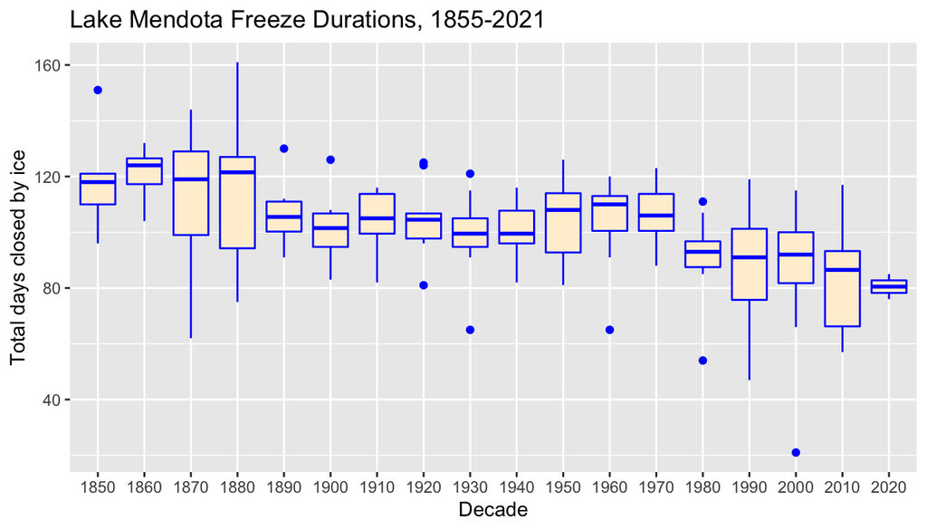

```r
ggplot(mendota, aes(x = as.character(decade), y = duration)) +
  geom_boxplot(fill = "papayawhip",
               color = "blue") +
  ylab("Total days closed by ice") +
  xlab("Decade") +
  ggtitle("Lake Mendota Freeze Durations, 1855-2021")
```

- We did this primarily to demonstrate how to create side-by-side boxplots.
- However, there is a better way:
  - Examine the relationship between `year1` and `duration` directly with an augmented scatter plot.

#### Scatter Plots

- A scatter plot summarizes two numerical variables by associating one with the x axis and the other with the y axis and plotting points.
- This R chunk displays a cloud of data points with `year1` specifying the location on the x axis and `duration` the location on the y axis.

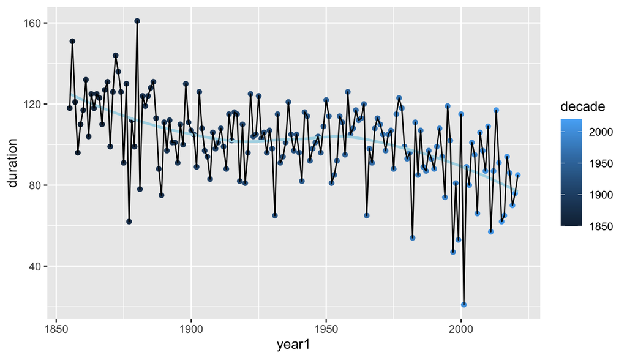

```r
ggplot(mendota, aes(x = year1, y = duration)) +
  geom_point(mapping = aes(color = decade)) +
  geom_smooth(se = FALSE, color = "lightblue") +
  geom_line()
```

##### Observations

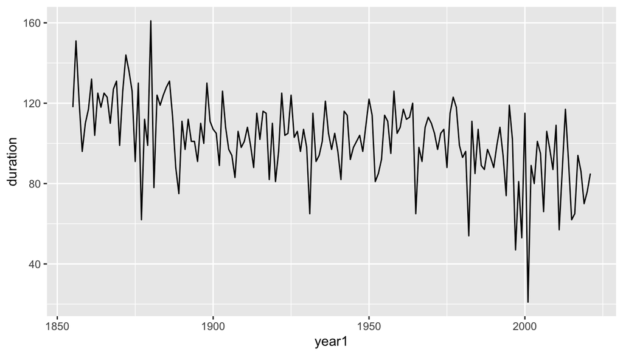

```r
ggplot(mendota, aes(x = year1, y = duration)) +
  geom_line()
```

- This graph makes it easier to see that there is a decreasing trend, but that the actual pattern of decrease is quite noisy with substantial year-to-year variation.
- Another geometry, `geom_smooth()`, greatly reduces the noise and replaces the actual data values with a smooth curve.

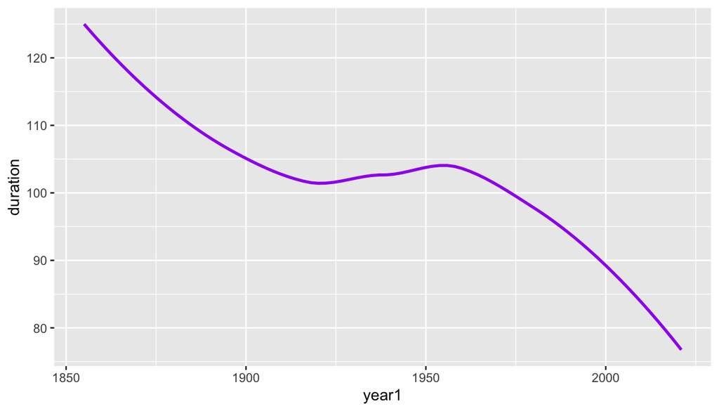

```r
ggplot(mendota, aes(x = year1, y = duration)) +
  geom_smooth(se = FALSE, color = "purple")
```

- The default graph produced with `geom_smooth()` draws a ribbon to represent uncertainty in the true value of the estimated trend line.
- We can discard this ribbon by setting the argument `se` (short for *standard error* which we will see later in the course) to be `FALSE`.

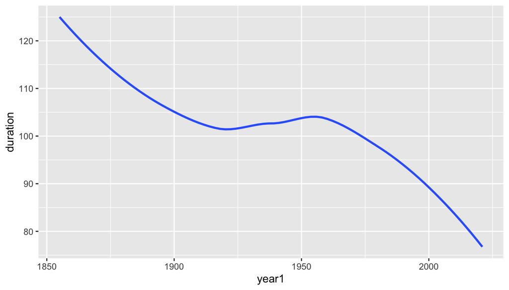

```r
ggplot(mendota, aes(x = year1, y = duration)) +
  geom_smooth(se = FALSE)
```

- After suppressing the year-to-year noise, we see a summarized pattern where the duration with which Lake Mendota has remained closed by ice in a typical year has decreased from over 120 days in 1850 to under 80 days at present.
  - There was a steady decline from 1850 to about 1920, followed by about 30–40 years of with a slight increase on average, followed by a decline at an even faster rate from about 1960 to the present.
  - Perhaps the rate of decrease is becoming steeper.

#### Scatter Plot with a Trend Line Added

- There is no reason to select only one of the previous plots.
- A better graphical display can be obtained by layering multiple pieces of the previous grpahs together.

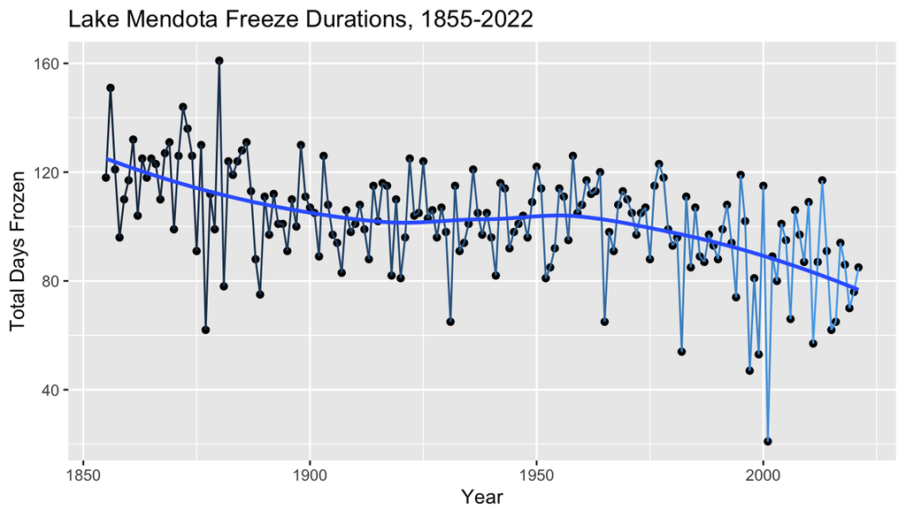

```r
## note setting the aesthetics here in ggplot()
## otherwise, we would need to set the in geom_point(), geom_line(), and geom_smooth() each separately
ggplot(mendota, aes(x=year1, y=duration)) +
  geom_point() +
  geom_line(mapping = aes(color = decade), show.legend = FALSE) +
  geom_smooth(se=FALSE) +
  xlab("Year") +
  ylab("Total Days Frozen") +
  ggtitle("Lake Mendota Freeze Durations, 1855-2022")
```

### Observations

- There does appear to be a decrease in the freeze durations over time
- Informally, we might interpret the blue curve as a description of what the climate is doing
  - ignoring year-to-year fluctuations, the typical average duration for Lake Mendota to freeze over the winter has decreased from about 120 days (or four months) in the mid 1850s to under 80 days (about 11 weeks) currently.
- The variation of the points around the blue curve may be interpreted as random “noise” caused by differences in the weather at key parts of the fall and winter seasons from year to year.

#### A basic model

- Later in the semester, we will investigate positing and fitting statistical models to study this.
- At present, informally, we can think of decomposing each point in the scatter plot as a sum of two parts:
  - A point on the blue curve we might name a “fitted value” which represents a statistical model-based estimate of what we might predict the Lake Mendota freeze duration to be in each specified year; and
  - A “residual” which is the difference between the actual value in a given winter and the fitted value.

$$\text{(actual value)} = \text{(fitted value)} + \text{(residual)}$$

- We will study model fitting similar to this later in the semester.
- We will study data manipulation next week.
- The following block of code, which you should not try to understand now, will add two columns to the `mendota` data set
  - a variable `smooth_fitted` which corresponds to the y-value of the blue curve for each year; and
  - a variable `smooth_residual` which is the difference between the actual observed value and the fitted value.

```r
## Fitting a model using code beyond the scope of this course
## The function `geom_smooth()` uses `loess()` under the hood
fit = loess(duration ~ year1, data = mendota)

## Add the values to the mendota data set
mendota = mendota %>%
  mutate(smooth_fitted = fit$fitted,
         smooth_residual = fit$residuals)
```

- With this modified Lake Mendota data set, we can ask some additional questions.

### Question 2

> In a typical year, how much does the actual duration for which Lake Mendota is frozen (the surface is at least 50% covered by ice) vary from its predicted value?
- To address this question, we want to explore some graphs of the `smooth_residual` variable.
- Let’s start with a density plot.

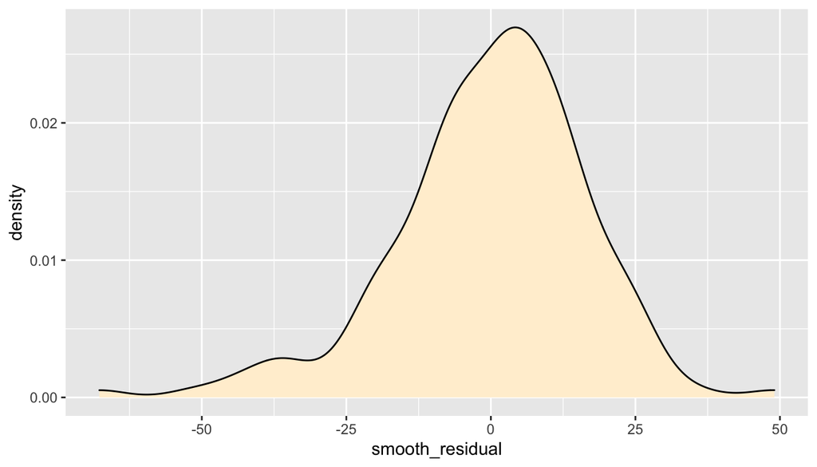

```r
ggplot(mendota, aes(x = smooth_residual)) +
  geom_density(fill = "papayawhip")
```

- From this plot, we see that the distribution of year to year annual variation around the trend curve is approximately bell-shaped and centered at zero, but there is some slight left skewness (the left tail is bigger than the right tail).

> It is more common for a winter where the actual duration for which Lake Mendota is closed by ice is extremely lower than typical than a winter where it is abnormally longer than typical.
- The scale of the plot indicates that it is not at all unusual for the actual duration Lake Mendota is closed by ice to differ from the trend line by about 2 to 3 weeks in either direction.
- Most of the area under the curve is between about -21 days and +21 days, but there are a fair number of years which exceed these typical values.
- We could also examine the distribution of the residuals around the smooth curve with a box plot.

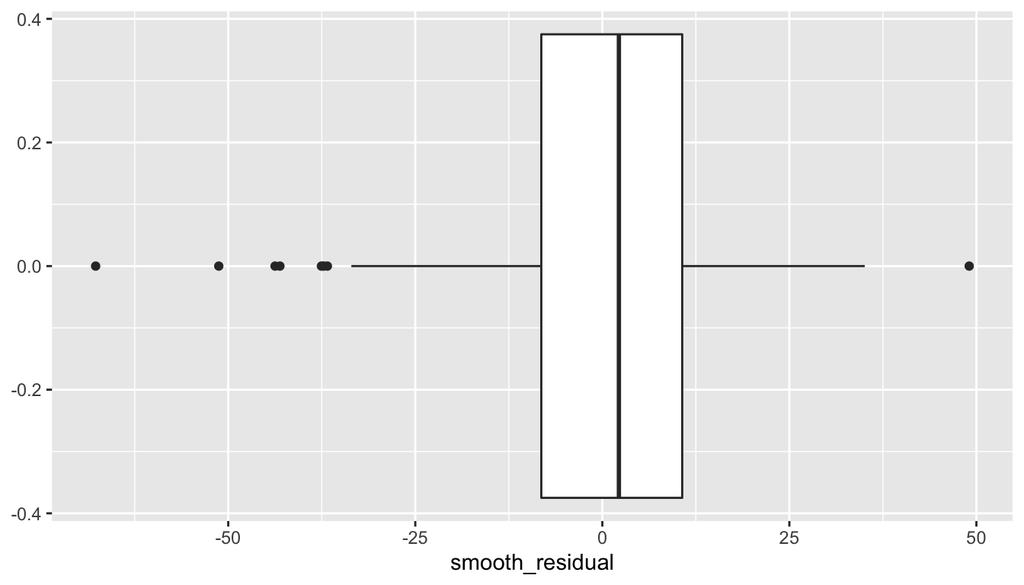

```r
ggplot(mendota, aes(x = smooth_residual)) +
  geom_boxplot()
```

#### Mean and Standard Deviation

- When we learn about **dplyr** next week, we will develop some skills for summarizing data.
- This block of code calculates:
  - the mean and median of the residuals around the smooth curve (these are meaures of the center of a distribution)
  - the standard deviation of the distribution (for a bell-shaped distribution, the standard deviation is the size of a “typical” distance from the mean).
  - several quantiles
- Do not worry about the code to produce these calculations until next week.

```r
mendota %>%
  summarize(mean = mean(smooth_residual),
            median = median(smooth_residual),
            sd = sd(smooth_residual),
            q10 = quantile(smooth_residual, 0.10),
            q25 = quantile(smooth_residual, 0.25),
            q50 = quantile(smooth_residual, 0.50),
            q75 = quantile(smooth_residual, 0.75),
            q90 = quantile(smooth_residual, 0.90))
```

```
## # A tibble: 1 × 8
##      mean median    sd   q10   q25   q50   q75   q90
##     <dbl>  <dbl> <dbl> <dbl> <dbl> <dbl> <dbl> <dbl>
## 1 -0.0577   2.22  16.7 -20.2 -8.16  2.22  10.7  18.8
```

- The mean of the distribution is close to 0
- The median is about 2 days above zero
- The standard deviation is 16.7 days, or a couple days longer than two weeks.
- Sometimes it is helpful to add vertical lines to a plot to help identify specific locations on the x axis.
- This next chunk of code adds vertical lines that are 1, 2, and 3 standard deviation below and above the center of zero.

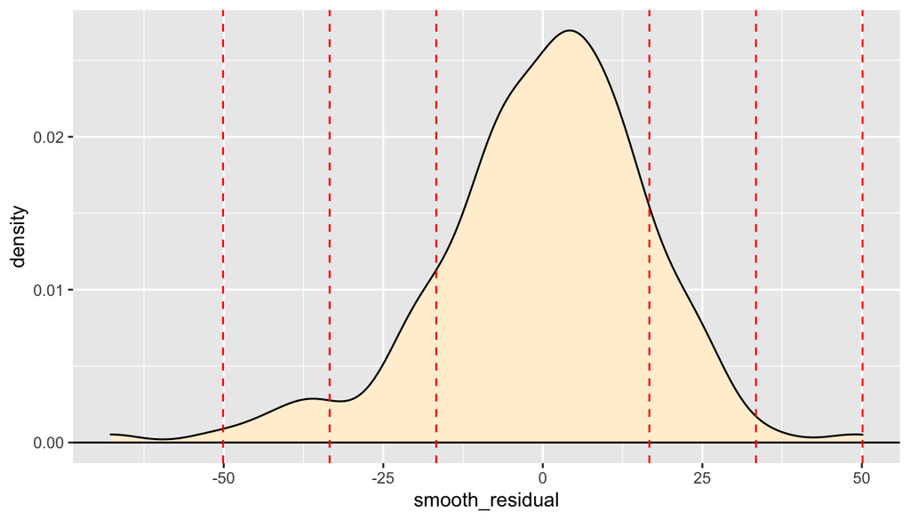

```r
ggplot(mendota, aes(x = smooth_residual)) +
  geom_density(fill = "papayawhip") +
  geom_hline(yintercept = 0) +
  geom_vline(xintercept = -3*16.7,
             color = "red", linetype = "dashed") +
  geom_vline(xintercept = -2*16.7,
             color = "red", linetype = "dashed") +
  geom_vline(xintercept = -1*16.7,
             color = "red", linetype = "dashed") +
  geom_vline(xintercept = 1*16.7,
             color = "red", linetype = "dashed") +
  geom_vline(xintercept = 2*16.7,
             color = "red", linetype = "dashed") +
  geom_vline(xintercept = 3*16.7,
             color = "red", linetype = "dashed")
```

- Symmetric bell-shaped solutions have the following approximate features (which are exactly true for an ideal normal distribution).
  - About 2/3 of the data is within one standard deviation of the mean, here between about 17 days above and below
  - About 95% of the observations are within two standard deviations of the mean
  - Nearly all of the observations are within three standard deviations of the mean
  - Here, our density is not perfectly ideal and there are likely a bit fewer than 95% of the values within two standard deviations with extras in the left tail of the distribution

### Axis Labels and Plot Titles

### Question 3

> When in the winter does Lake Mendota typically close with ice the first time?
- To answer this question graphically, I decided to create a new variable which categorizes the date of the first freeze into a half-month time period, from “Nov 16-30” through “Jan 16-31”
  - (the earliest date Lake Mendota closed with ice was November 23 during the winter of 1880-81 and the latest date Lake Mendota closed with ice was January 30 during the winter of 1931-32).
- The variable `ff_x` counts the number of days after June 30 of the corresponding winter.
  - For example, November 30 is 153 days after June 30 each year.
- The following block of code uses commands from **dplyr** to transform the data by adding new columns, **lubridate** to work with dates, and **stringr** to work with strings.
- **Do not worry about this code yet.**

```r
mendota = mendota %>%
  mutate(ff_x = as.integer(first_freeze -
                             ymd(str_c(year1,"-06-30"))),
         ff_cat = case_when(
           ff_x <= 153 ~ "Nov 16-30",
           ff_x <= 168 ~ "Dec 1-15",
           ff_x <= 184 ~ "Dec 16-31",
           ff_x <= 199 ~ "Jan 1-15",
           ff_x <= 215 ~ "Jan 16-30")) %>%
  mutate(ff_cat = reorder(ff_cat, ff_x))

mendota_sum = mendota %>%
  count(ff_cat)
```

- Our new variable of interest is named `ff_cat` and it categorizes the date of the first freeze.
- We also have a new summary data frame named `mendota_sum` with the counts of how many winters fall into each category.

```r
mendota %>%
  select(winter, duration, first_freeze, ff_cat) %>%
  slice_head(n=5)
```

```
## # A tibble: 5 × 4
##   winter  duration first_freeze ff_cat
##   <chr>      <dbl> <date>       <fct>
## 1 1855-56      118 1855-12-18   Dec 16-31
## 2 1856-57      151 1856-12-06   Dec 1-15
## 3 1857-58      121 1857-11-25   Nov 16-30
## 4 1858-59       96 1858-12-08   Dec 1-15
## 5 1859-60      110 1859-12-07   Dec 1-15
```

```r
mendota_sum
```

```
## # A tibble: 5 × 2
##   ff_cat        n
##   <fct>     <int>
## 1 Nov 16-30     4
## 2 Dec 1-15     47
## 3 Dec 16-31    80
## 4 Jan 1-15     34
## 5 Jan 16-30     2
```

# Friday Preview

- The notes below are incomplete
- I will add more detail before Friday
- These are here in case I finish early on Wednesday

### Bar Graphs

- A bar graph is a common way to display the counts of a categorical variable.
- The **ggplot2** command `geom_bar()` is used to create bar graphs from a data set where the heights of the bars need t be calculated.
- In contrast, the **ggplot2** command `geom_col()` is used when there is one column for the categorical variable and another column which contains the heights of the bars.

#### geom_bar()

- This code creates a bar graph from the `ff_cat` variable of the `mendota` data set.
  - The bar heights are calculated by counting the number of winters in each category.

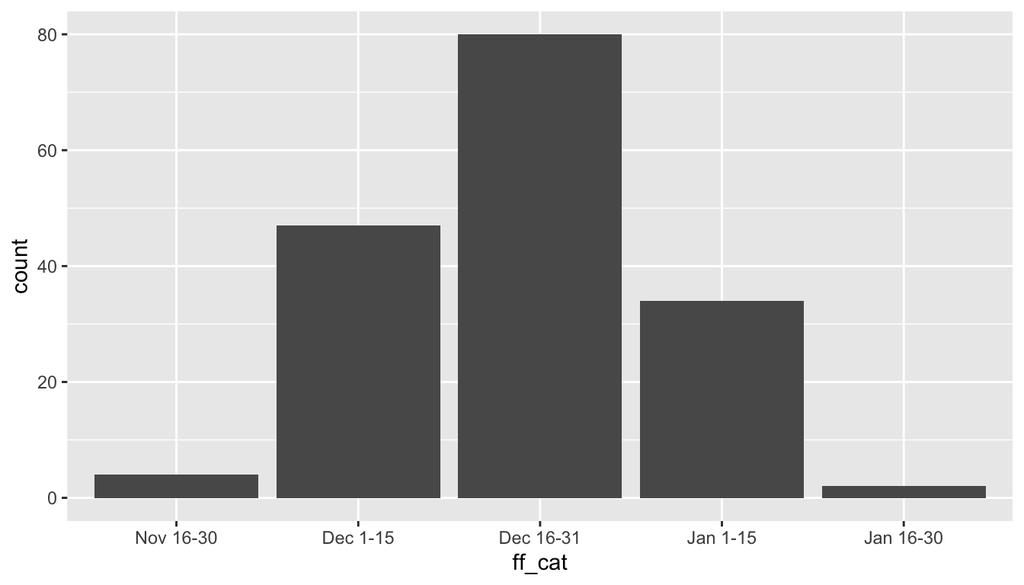

```r
ggplot(mendota, aes(x = ff_cat)) +
  geom_bar()
```

- We can add layers to improve the appearance.

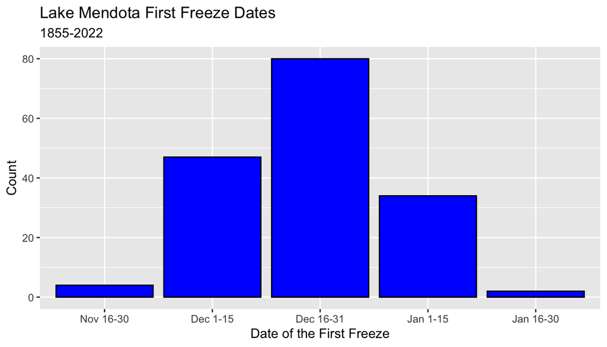

```r
ggplot(mendota, aes(x = ff_cat)) +
  geom_bar(color = "black", fill = "blue") +
  xlab("Date of the First Freeze") +
  ylab("Count") +
  ggtitle("Lake Mendota First Freeze Dates",
          subtitle = "1855-2022")
```

#### geom_col()

- Here a table with the summary counts

```r
mendota_sum
```

```
## # A tibble: 5 × 2
##   ff_cat        n
##   <fct>     <int>
## 1 Nov 16-30     4
## 2 Dec 1-15     47
## 3 Dec 16-31    80
## 4 Jan 1-15     34
## 5 Jan 16-30     2
```

- Use `geom_col()` and set both `x` and `y` aesthetics.

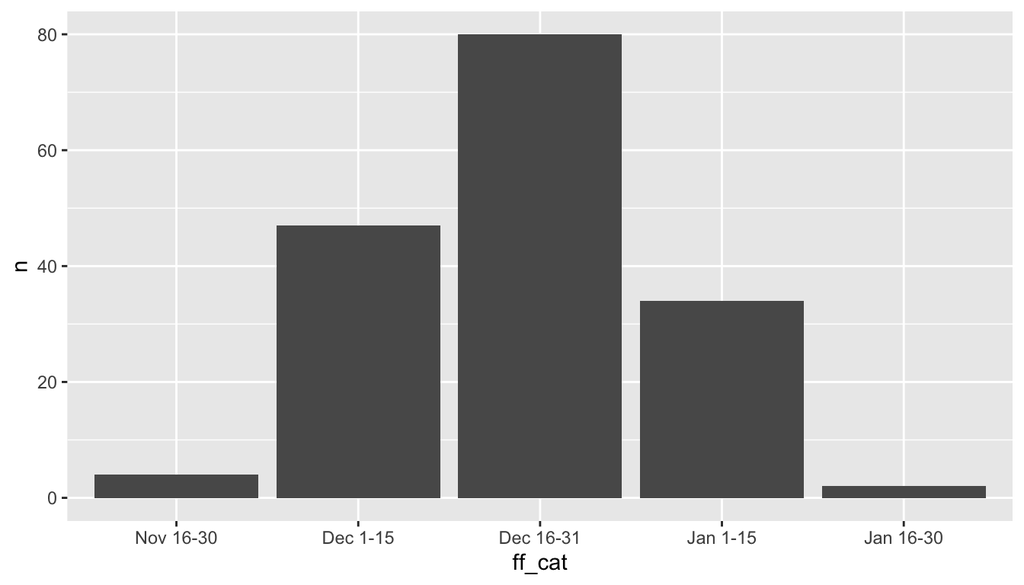

```r
ggplot(mendota_sum, aes(x = ff_cat, y = n)) +
  geom_col()
```

- Again, make the graph better for presentation.

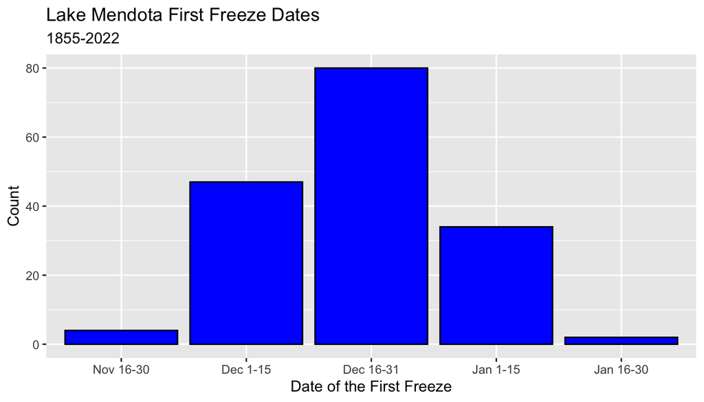

```r
ggplot(mendota_sum, aes(x = ff_cat, y = n)) +
  geom_col(color = "black", fill = "blue") +
  xlab("Date of the First Freeze") +
  ylab("Count") +
  ggtitle("Lake Mendota First Freeze Dates",
          subtitle = "1855-2022")
```

### Facets

```r
mendota = mendota %>%
  mutate(period = case_when(
    year1 < 1901 ~ "1855-1900",
    year1 < 1951 ~ "1901-1950",
    year1 < 2001 ~ "1951-2000",
    TRUE ~ "2001-2022"))
```

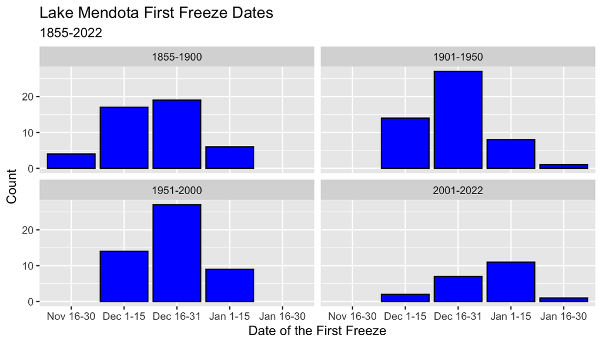

```r
ggplot(mendota, aes(x = ff_cat)) +
  geom_bar(color = "black", fill = "blue") +
  xlab("Date of the First Freeze") +
  ylab("Count") +
  ggtitle("Lake Mendota First Freeze Dates",
          subtitle = "1855-2022") +
  facet_wrap(~period)
```

```r
mendota_sum2 = mendota %>%
  count(period, ff_cat) %>%
  group_by(period) %>%
  mutate(p = n / sum(n),
         pct = 100*p)
```

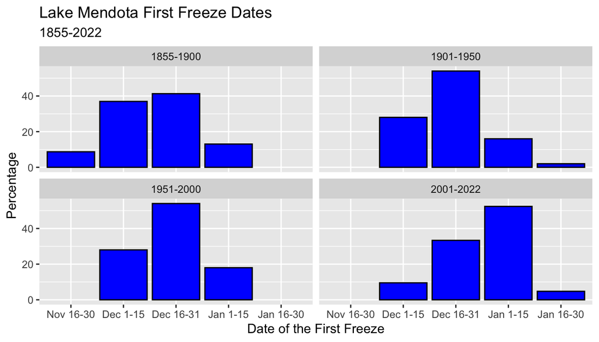

```r
ggplot(mendota_sum2, aes(x = ff_cat, y = pct)) +
  geom_col(color = "black", fill = "blue") +
  xlab("Date of the First Freeze") +
  ylab("Percentage") +
  ggtitle("Lake Mendota First Freeze Dates",
          subtitle = "1855-2022") +
  facet_wrap(~period)
```

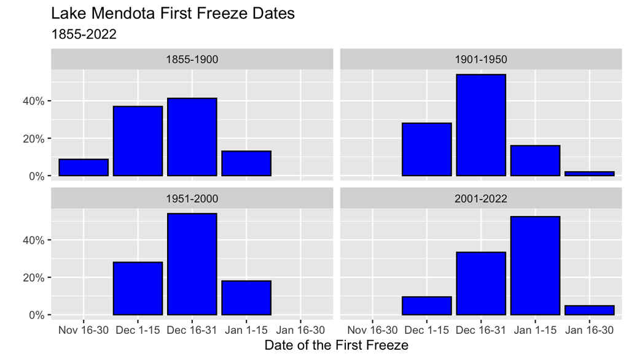

```r
ggplot(mendota_sum2, aes(x = ff_cat, y = p)) +
  geom_col(color = "black", fill = "blue") +
  scale_y_continuous(labels = scales::percent) +
  xlab("Date of the First Freeze") +
  ylab("") +
  ggtitle("Lake Mendota First Freeze Dates",
          subtitle = "1855-2022") +
  facet_wrap(~period)
```

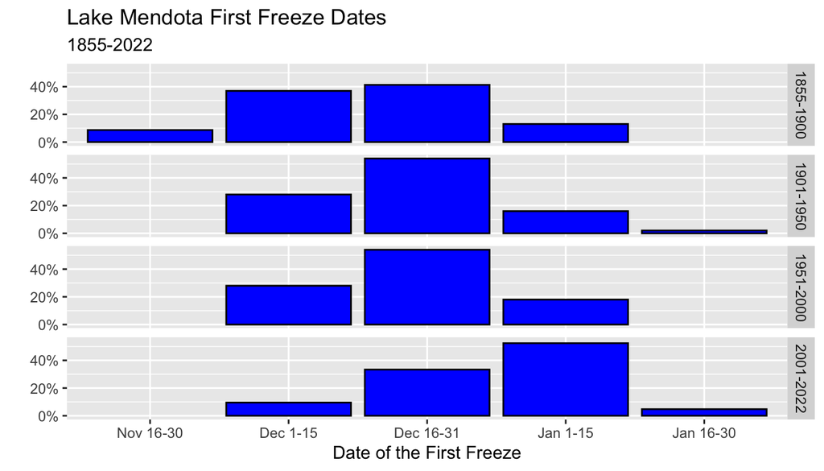

```r
ggplot(mendota_sum2, aes(x = ff_cat, y = p)) +
  geom_col(color = "black", fill = "blue") +
  scale_y_continuous(labels = scales::percent) +
  xlab("Date of the First Freeze") +
  ylab("") +
  ggtitle("Lake Mendota First Freeze Dates",
          subtitle = "1855-2022") +
  facet_grid(rows = vars(period))
```

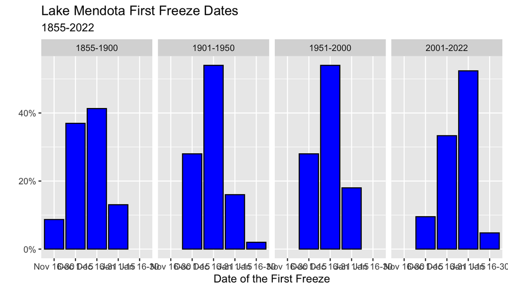

```r
ggplot(mendota_sum2, aes(x = ff_cat, y = p)) +
  geom_col(color = "black", fill = "blue") +
  scale_y_continuous(labels = scales::percent) +
  xlab("Date of the First Freeze") +
  ylab("") +
  ggtitle("Lake Mendota First Freeze Dates",
          subtitle = "1855-2022") +
  facet_grid(cols = vars(period))
```

### Adding Color

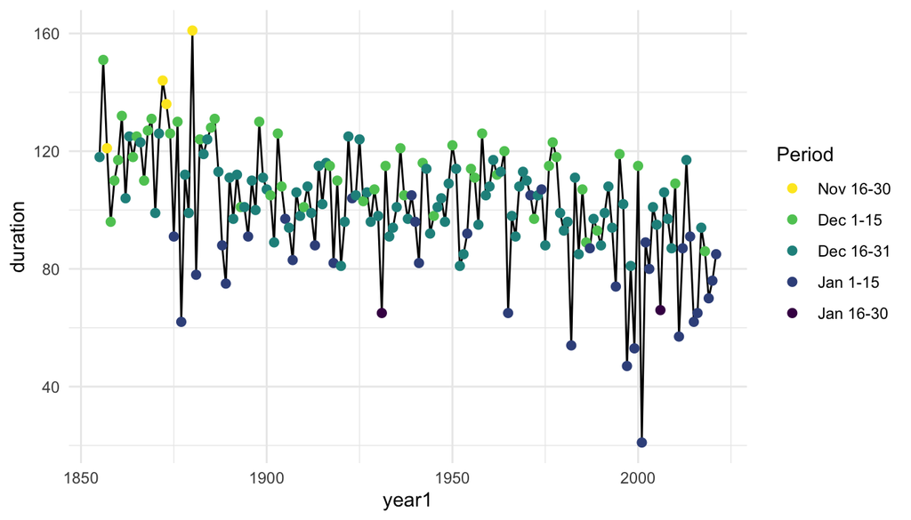

```r
ggplot(mendota, aes(x = year1, y = duration)) +
  geom_line() +
  geom_point(aes(col = ff_cat), size = 2) +
  scale_color_viridis_d(direction = -1) +
  guides(color = guide_legend(title = "Period")) +
  theme_minimal()
```